# Midterm Decision

## Analysis

In this analysis, we’ll use previous students’ scores to determine whether I should drop or keep my midterm score.

## Final Decision

```r
grades.loess <- loess(FinalExam ~ Midterm, data=grades, span=.75, degree=2)

midterm.score <- 72
predicted.final <- predict(grades.loess, data.frame(Midterm = 72), interval = 'prediction')
```

Using the LOESS model, with a midterm of *72* my final exam predicted score is **63.01**.

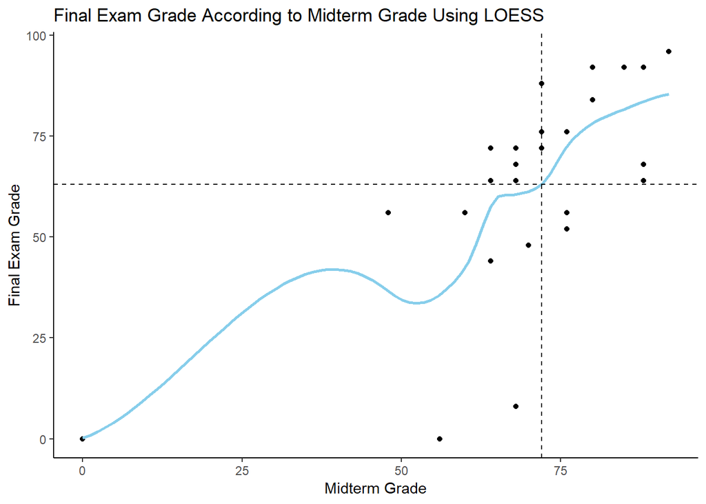

```r
grades %>%
  ggplot(aes(Midterm, FinalExam)) +
  geom_point() +
  geom_smooth(method="loess", se=F, span=.75, method.args=list(degree=2), color="skyblue") +
  geom_hline(aes(yintercept=predicted.final), color="black", linetype="dashed") +
  geom_vline(aes(xintercept=midterm.score), color="black", linetype="dashed") +
  labs(title="Final Exam Grade According to Midterm Grade Using LOESS", x="Midterm Grade", y="Final Exam Grade") +
  theme_classic() +
  theme(panel.grid = element_blank())
```

Now fitting a simple linear model, my final exam predicted score is **64.35**, or we’re 95% confident it will be anything between 20.68 and 100.

```r
grades.lm <- lm(FinalExam ~ Midterm, data=grades)

midterm.score <- 72
predicted.final <- predict(grades.lm, data.frame(Midterm = midterm.score), interval = 'prediction')
```

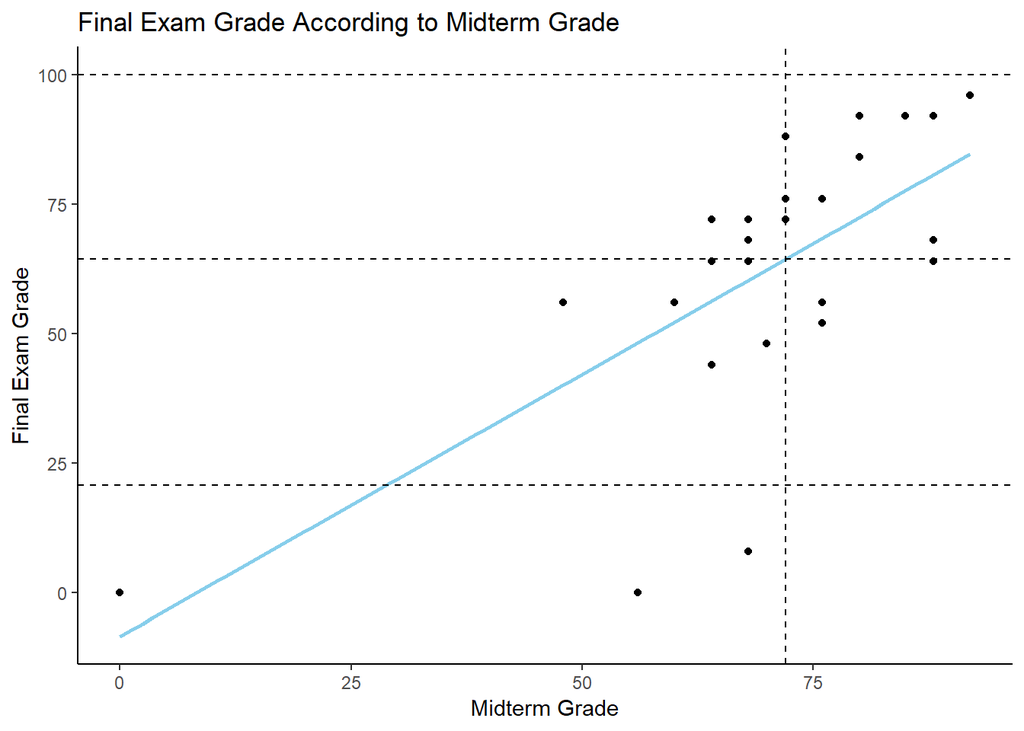

```r
grades %>%
  ggplot(aes(Midterm, FinalExam)) +
  geom_point() +
  geom_smooth(method="lm", se=F, color='skyblue') +
  geom_hline(aes(yintercept=64.35), color="black", linetype="dashed") +
  geom_hline(aes(yintercept=20.68), color="black", linetype="dashed") +
  geom_hline(aes(yintercept=100), color="black", linetype="dashed") +
  geom_vline(aes(xintercept=midterm.score), color="black", linetype="dashed") +
  labs(title="Final Exam Grade According to Midterm Grade", x="Midterm Grade", y="Final Exam Grade") +
  theme_classic() +
  theme(panel.grid = element_blank())
```

After seeing both predictions, I will **NOT DROP** my midterm score. This is because while it is true the interval prediction using a linear model includes an A (100%), both fitted predictions are lower than my midterm, so most likely I’ll do worse. I prefer to secure my midterm points and not drop them.

## Technical Details

#### Creating the Model

We looked at the pairs of numerical variables present in our dataset to determine any patterns.

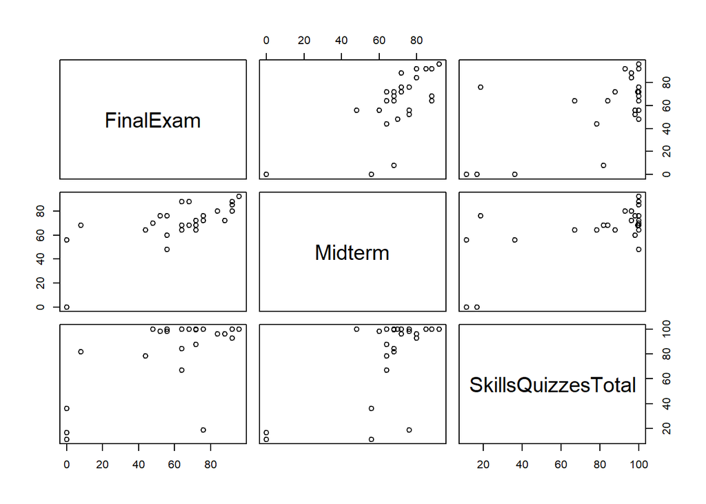

```r
pairs(grades[2:4])
```

We can see that the variable Midterm is the one with some trend or pattern, when plotted agains the variable FinalExam. So we’ll get a model that looks like this:

$$\underbrace{Y_i}_\text{Final} = \beta_0 + \beta_1 \underbrace{X_i}_\text{Midterm} + \epsilon_i \quad \text{where} \ \epsilon_i \sim N(0, \sigma^2)$$
where our null hypothesis is that the slope is not zero and our alpha level is 0.05.

```r
pander(summary(grades.lm))
```

|  | Estimate | Std. Error | t value | Pr(>\|t\|) |
| --- | --- | --- | --- | --- |
| **(Intercept)** | -8.454 | 12.97 | -0.6517 | 0.5201 |
| **Midterm** | 1.011 | 0.1863 | 5.431 | 9.595e-06 |

Fitting linear model: FinalExam ~ Midterm

| Observations | Residual Std. Error | $R^2$ | Adjusted $R^2$ |
| --- | --- | --- | --- |
| 29 | 20.91 | 0.5221 | 0.5044 |

We see the p-value of the slope is very significant which further corroborates the Midterm predictor is good for our model, but our R-squared score of 0.5 is not that good, yet is not bad either, so it’s not the best model at explaining the variation of the data.

#### Checking Assumptions

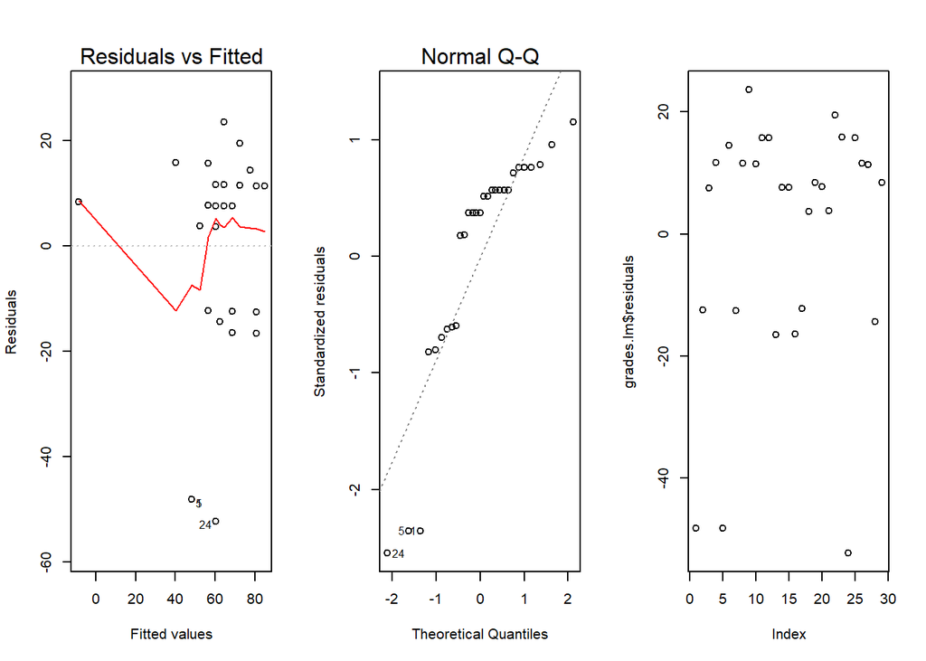

```r
par(mfrow = c(1,3))
plot(grades.lm, which = 1:2)
plot(grades.lm$residuals)
```

In the first plot we see that the variance is not that good, but if we removed the outliers, I think it would look normal. The qq-plot of residuals violates normality. Overall, I think we shouldn’t trust this model, or get more data and re-do the model.